# student performance2.0

Alex Constantinescu & Matei Grosu

1/8/2022

## Introduction

We have taken a data set on the student performance on exams regarding math,reading and writing scores. The data set is taken from https://www.kaggle.com/spscientist/students-performance-in-exams We have searched for a data set that is already cleaned. The data set provides information on the student performance at reading writing and math exams together with data about gender, race,parental education,lunch and test preparation . In this report we will explore the data and analyse it.Specifically, we’ll use data visualisation and transformation to explore the choosen data set.

Question: 1.What type of variation occurs within the variables?

2.What type of covariation occurs between the variables?

## Import data

First, we have to import the data set into the rStudio environment so that we can start explore the data and analyse it.

```r
stPerform <- read_csv("/Users/alex/Desktop/UNIVERSITY/SEM3/DASC/StudentsPerformance.csv")
stPerform
```

```
## # A tibble: 1,000 × 8
##    gender `race/ethnicity` `parental level … lunch `test preparati… `math score`
##    <chr>  <chr>            <chr>             <chr> <chr>                   <dbl>
##  1 female group B          bachelor's degree stan… none                       72
##  2 female group C          some college      stan… completed                  69
##  3 female group B          master's degree   stan… none                       90
##  4 male   group A          associate's degr… free… none                       47
##  5 male   group C          some college      stan… none                       76
##  6 female group B          associate's degr… stan… none                       71
##  7 female group B          some college      stan… completed                  88
##  8 male   group B          some college      free… none                       40
##  9 male   group D          high school       free… completed                  64
## 10 female group B          high school       free… none                       38
## # … with 990 more rows, and 2 more variables: reading score <dbl>,
## #   writing score <dbl>
```

## Displaying the internal structure of the data frame:

```r
str(stPerform)
```

```
## spec_tbl_df [1,000 × 8] (S3: spec_tbl_df/tbl_df/tbl/data.frame)
##  $ gender                     : chr [1:1000] "female" "female" "female" "male" ...
##  $ race/ethnicity             : chr [1:1000] "group B" "group C" "group B" "group A" ...
##  $ parental level of education: chr [1:1000] "bachelor's degree" "some college" "master's degree" "associate's degree" ...
##  $ lunch                      : chr [1:1000] "standard" "standard" "standard" "free/reduced" ...
##  $ test preparation course    : chr [1:1000] "none" "completed" "none" "none" ...
##  $ math score                 : num [1:1000] 72 69 90 47 76 71 88 40 64 38 ...
##  $ reading score              : num [1:1000] 72 90 95 57 78 83 95 43 64 60 ...
##  $ writing score              : num [1:1000] 74 88 93 44 75 78 92 39 67 50 ...
##  - attr(*, "spec")=
##   .. cols(
##   ..   gender = col_character(),
##   ..   `race/ethnicity` = col_character(),
##   ..   `parental level of education` = col_character(),
##   ..   lunch = col_character(),
##   ..   `test preparation course` = col_character(),
##   ..   `math score` = col_double(),
##   ..   `reading score` = col_double(),
##   ..   `writing score` = col_double()
##   .. )
##  - attr(*, "problems")=<externalptr>
```

## Some descriptive information of the data:

```r
summary(stPerform)
```

```
##     gender          race/ethnicity     parental level of education
##  Length:1000        Length:1000        Length:1000
##  Class :character   Class :character   Class :character
##  Mode  :character   Mode  :character   Mode  :character
##
##
##
##     lunch           test preparation course   math score     reading score
##  Length:1000        Length:1000             Min.   :  0.00   Min.   : 17.00
##  Class :character   Class :character        1st Qu.: 57.00   1st Qu.: 59.00
##  Mode  :character   Mode  :character        Median : 66.00   Median : 70.00
##                                             Mean   : 66.09   Mean   : 69.17
##                                             3rd Qu.: 77.00   3rd Qu.: 79.00
##                                             Max.   :100.00   Max.   :100.00
##  writing score
##  Min.   : 10.00
##  1st Qu.: 57.75
##  Median : 69.00
##  Mean   : 68.05
##  3rd Qu.: 79.00
##  Max.   :100.00
```

From the descriptive information of the data we understood of what types are the data’s variables. We have continous variables(math score, reading score and writing score) and categorical variables(gender,race/ethnicity, parental level of education, lunch, test preparation). Also, we want to search for missing values and than to rename the column names to be easier to work with

## Trying to tidy the data

The column names are not that good to work with so we decided to rename them in order to be easier to work with.

```r
colnames(stPerform)<-c("Gender","Race","Parental_Education","Lunch","Test_Prep","Math_Score","Reading_Score","Writing_Score")
head(stPerform)
```

```
## # A tibble: 6 × 8
##   Gender Race    Parental_Education Lunch     Test_Prep Math_Score Reading_Score
##   <chr>  <chr>   <chr>              <chr>     <chr>          <dbl>         <dbl>
## 1 female group B bachelor's degree  standard  none              72            72
## 2 female group C some college       standard  completed         69            90
## 3 female group B master's degree    standard  none              90            95
## 4 male   group A associate's degree free/red… none              47            57
## 5 male   group C some college       standard  none              76            78
## 6 female group B associate's degree standard  none              71            83
## # … with 1 more variable: Writing_Score <dbl>
```

We want to find out if there are any missing values to deal with Dealing with missing values:

Count missing values:

```r
sum(is.na(stPerform))
```

```
## [1] 0
```

We do not have missing values.

## Let’s create a new column for the average score at all subjects

```r
stPerformAvg <- mutate(stPerform,
       avgScore = (Math_Score+Reading_Score+Writing_Score)/3)
stPerformAvg
```

```
## # A tibble: 1,000 × 9
##    Gender Race    Parental_Education Lunch    Test_Prep Math_Score Reading_Score
##    <chr>  <chr>   <chr>              <chr>    <chr>          <dbl>         <dbl>
##  1 female group B bachelor's degree  standard none              72            72
##  2 female group C some college       standard completed         69            90
##  3 female group B master's degree    standard none              90            95
##  4 male   group A associate's degree free/re… none              47            57
##  5 male   group C some college       standard none              76            78
##  6 female group B associate's degree standard none              71            83
##  7 female group B some college       standard completed         88            95
##  8 male   group B some college       free/re… none              40            43
##  9 male   group D high school        free/re… completed         64            64
## 10 female group B high school        free/re… none              38            60
## # … with 990 more rows, and 2 more variables: Writing_Score <dbl>,
## #   avgScore <dbl>
```

## Data Viualization:

# we want to see how females did in there exams, let’s create a new table only with the females:

```r
fPerform <-filter(stPerformAvg,Gender=="female")
fPerform
```

```
## # A tibble: 518 × 9
##    Gender Race    Parental_Education Lunch    Test_Prep Math_Score Reading_Score
##    <chr>  <chr>   <chr>              <chr>    <chr>          <dbl>         <dbl>
##  1 female group B bachelor's degree  standard none              72            72
##  2 female group C some college       standard completed         69            90
##  3 female group B master's degree    standard none              90            95
##  4 female group B associate's degree standard none              71            83
##  5 female group B some college       standard completed         88            95
##  6 female group B high school        free/re… none              38            60
##  7 female group B high school        standard none              65            81
##  8 female group A master's degree    standard none              50            53
##  9 female group C some high school   standard none              69            75
## 10 female group B some high school   free/re… none              18            32
## # … with 508 more rows, and 2 more variables: Writing_Score <dbl>,
## #   avgScore <dbl>
```

# let’s see the distribution of scores for females

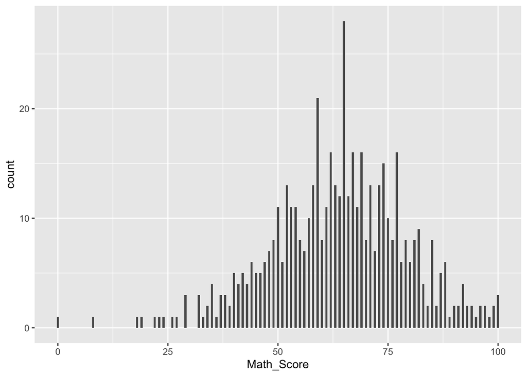

```r
ggplot(data = fPerform) +
  geom_histogram(mapping = aes(x = Math_Score), binwidth = 0.5)
```

## Let’s do the same thing for the males,so let’s create a table only with males

```r
mPerform <-filter(stPerformAvg,Gender=="male")
mPerform
```

```
## # A tibble: 482 × 9
##    Gender Race    Parental_Education Lunch    Test_Prep Math_Score Reading_Score
##    <chr>  <chr>   <chr>              <chr>    <chr>          <dbl>         <dbl>
##  1 male   group A associate's degree free/re… none              47            57
##  2 male   group C some college       standard none              76            78
##  3 male   group B some college       free/re… none              40            43
##  4 male   group D high school        free/re… completed         64            64
##  5 male   group C associate's degree standard none              58            54
##  6 male   group D associate's degree standard none              40            52
##  7 male   group A some college       standard completed         78            72
##  8 male   group C high school        standard none              88            89
##  9 male   group C master's degree    free/re… completed         46            42
## 10 male   group D high school        standard none              66            69
## # … with 472 more rows, and 2 more variables: Writing_Score <dbl>,
## #   avgScore <dbl>
```

# let’s see the distribution of scores for males

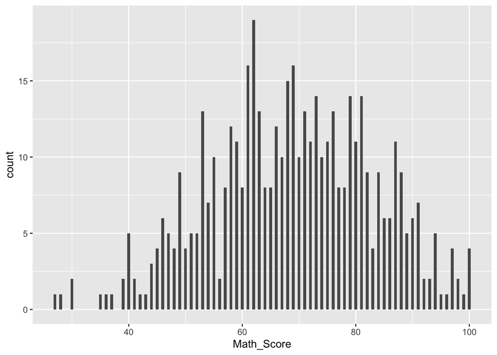

```r
ggplot(data = mPerform) +
  geom_histogram(mapping = aes(x = Math_Score), binwidth = 0.5)
```

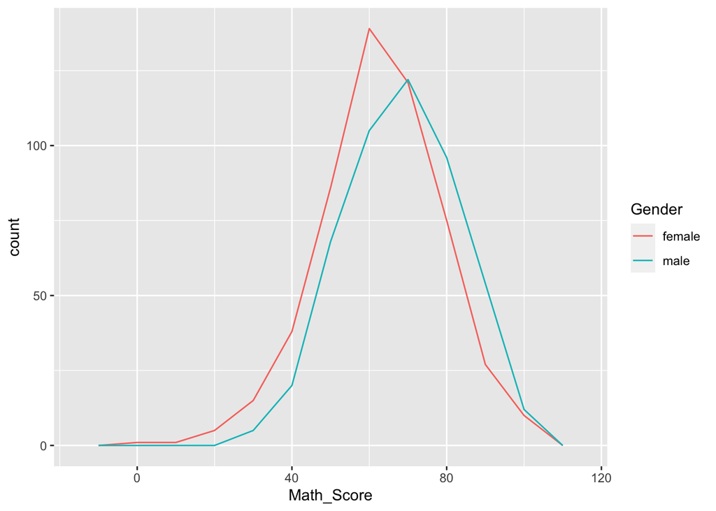

```r
ggplot(data = stPerformAvg, mapping = aes(x = Math_Score, colour = Gender)) +
  geom_freqpoly(binwidth = 10)
```

Creating a ggplot to visualize the relationship between math scores and average scores related to gender.

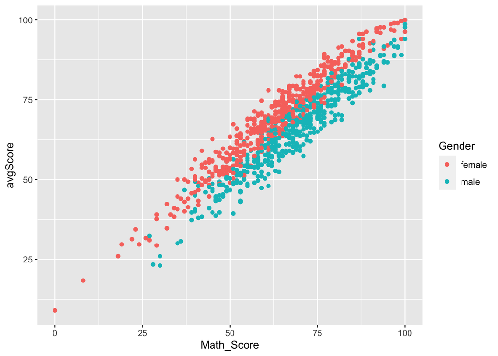

```r
ggplot(data = stPerformAvg) +
  geom_point(mapping = aes(x =Math_Score , y =avgScore, color=Gender))
```

More plots:

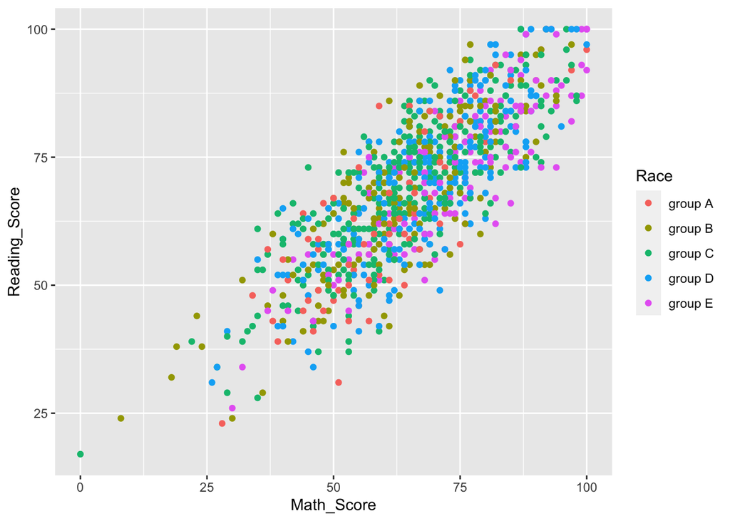

```r
ggplot(data = stPerform) +
  geom_point(mapping = aes(x =Math_Score , y =Reading_Score, color=Race))
```

This plot does not help us too much as it is not that clear the distribution of race groups.

Let’s try to visualize the distribution of the races

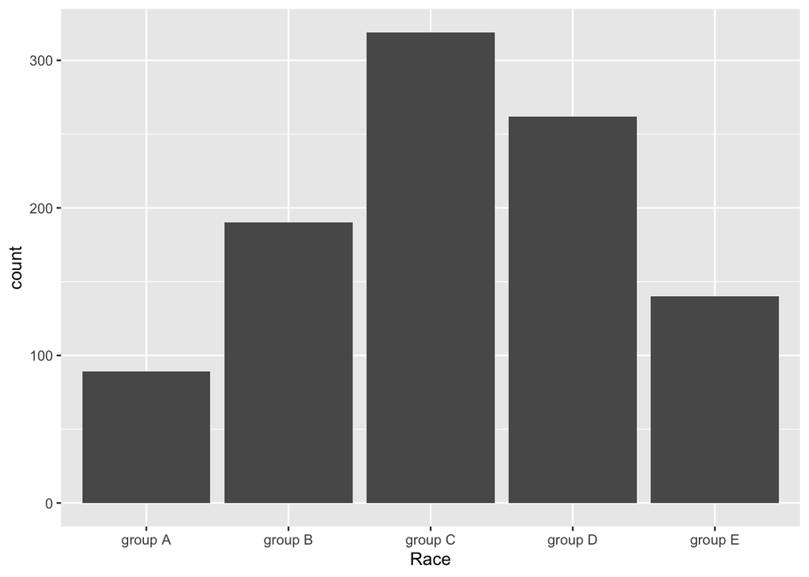

```r
ggplot(data = stPerform) +
  geom_bar(mapping = aes(x = Race))
```

## Let’s see how the parental educatian affects the scores of the students

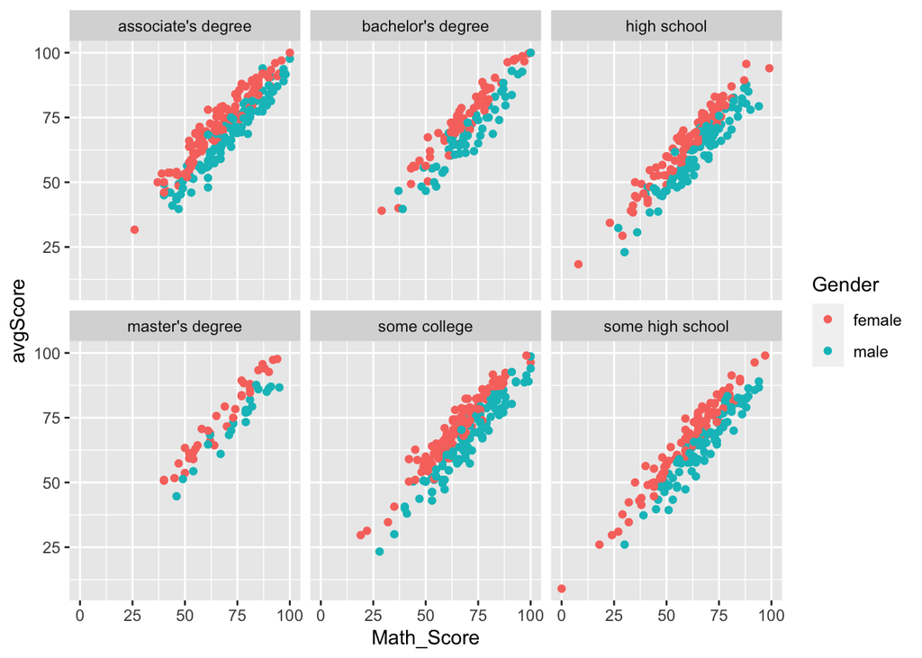

```r
ggplot(data = stPerformAvg) +
  geom_point(mapping = aes(x =Math_Score , y =avgScore, color=Gender ))+
  facet_wrap(~ Parental_Education,nrow = 2)
```

## Let’s see the distribution of average scores:

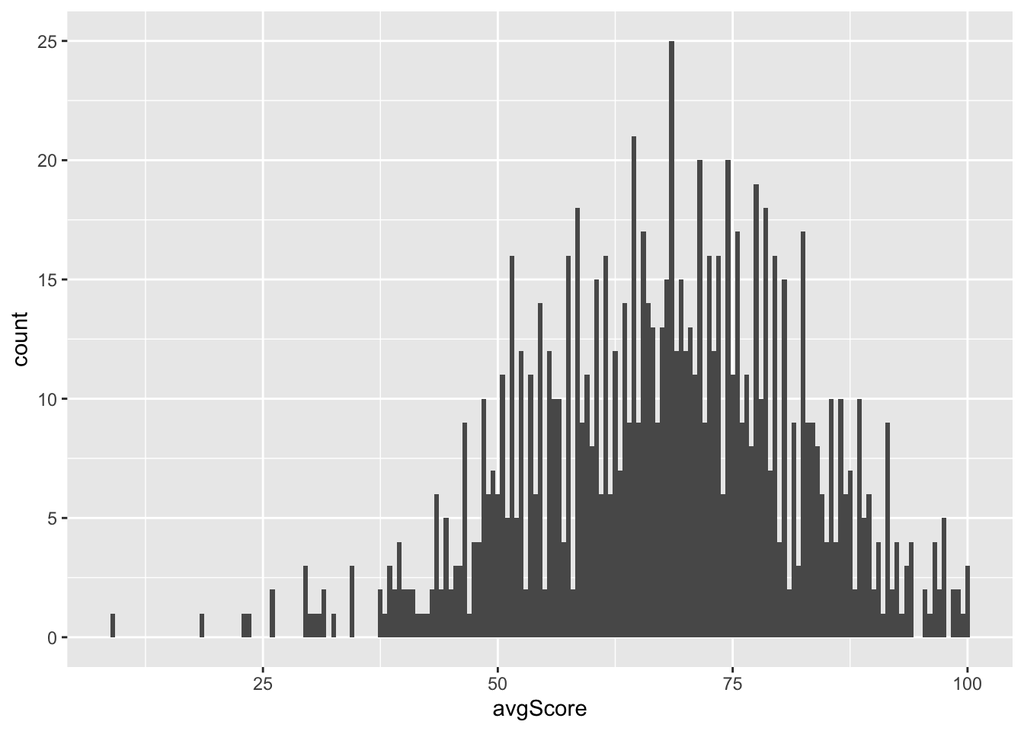

```r
ggplot(data = stPerformAvg) +
  geom_histogram(mapping = aes(x = avgScore), binwidth = 0.5)
```

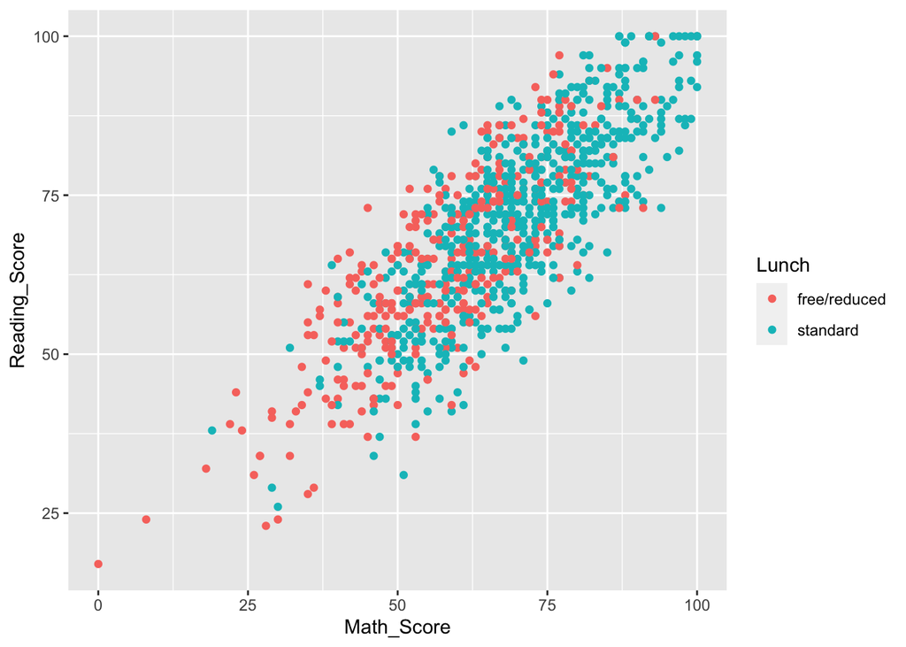

```r
ggplot(data = stPerform) +
  geom_point(mapping = aes(x =Math_Score , y =Reading_Score, color=Lunch))
```

## Plot exam scores by gender to determinate if there is a different score tendency for each gender

#Math scores by gender:

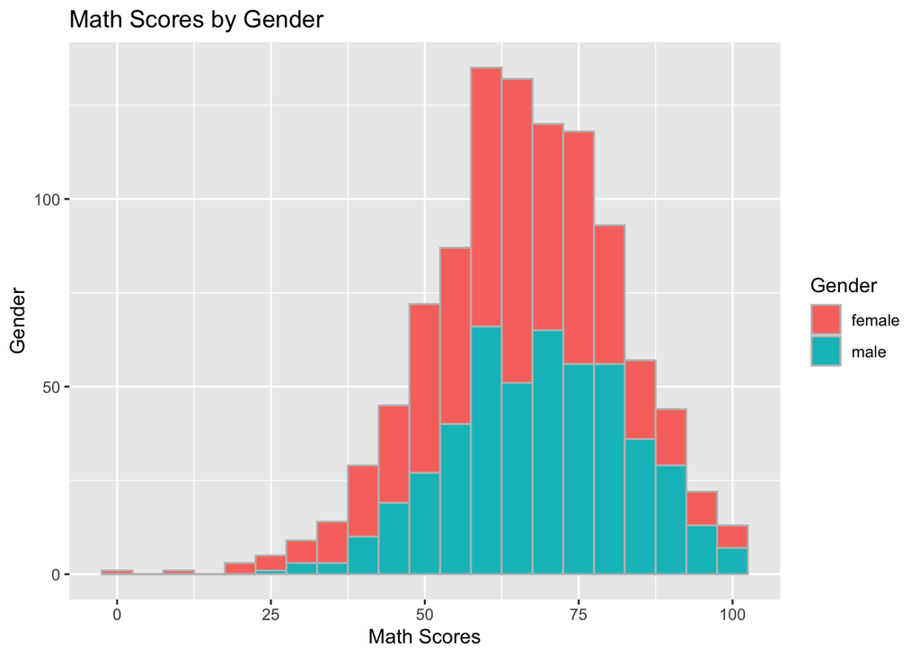

```r
pl <- ggplot(stPerformAvg, aes(Math_Score)) + geom_histogram(binwidth=5, color="gray", aes(fill=Gender))
pl <- pl + xlab("Math Scores") + ylab("Gender") + ggtitle("Math Scores by Gender")
pl
```

#Reading scores by gender:

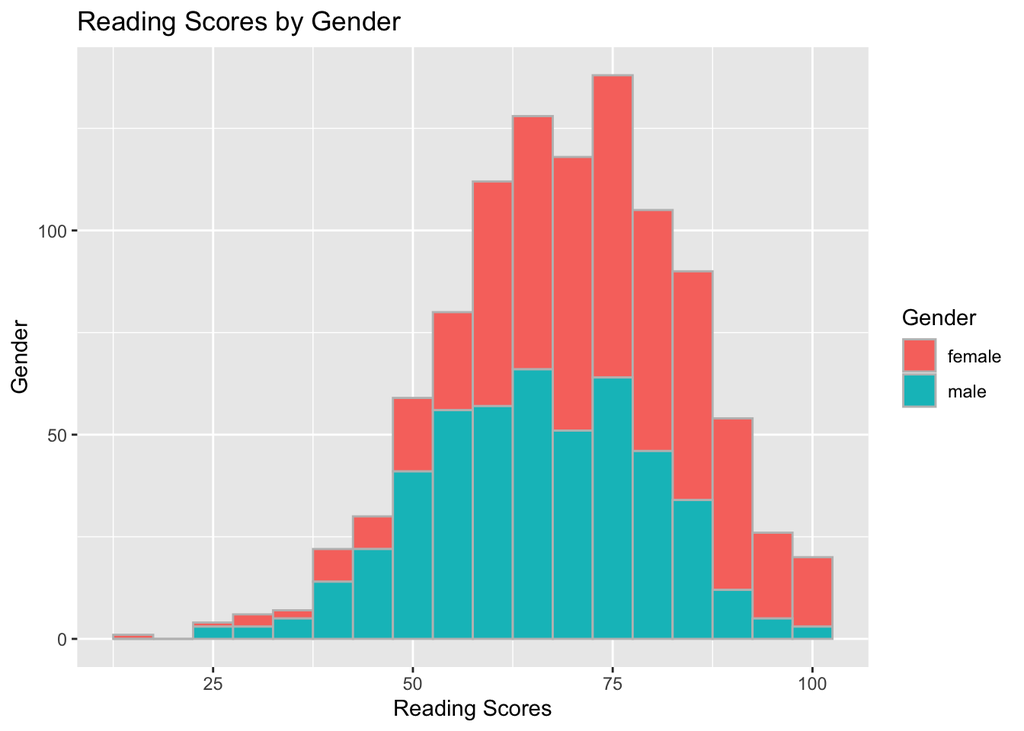

```r
pl1 <- ggplot(stPerformAvg, aes(Reading_Score)) + geom_histogram(binwidth=5, color="gray", aes(fill=Gender))
pl1 <- pl1 + xlab("Reading Scores") + ylab("Gender") + ggtitle("Reading Scores by Gender")
pl1
```

# Writing scores by gender:

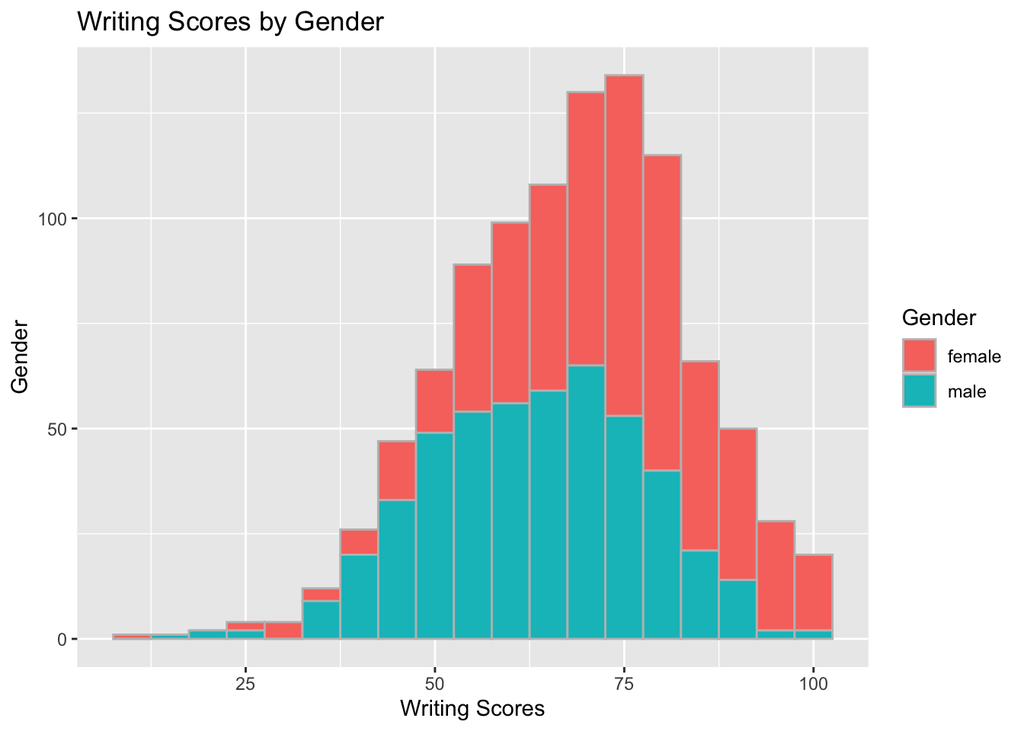

```r
pl2 <- ggplot(stPerformAvg, aes(Writing_Score)) +  geom_histogram(binwidth=5, color="gray", aes(fill=Gender))
pl2 <- pl2 + xlab("Writing Scores") + ylab("Gender") + ggtitle("Writing Scores by Gender")
pl2
```

# Average score by gender:

[figure not shown]

```r
pl3 <- ggplot(stPerformAvg, aes(avgScore)) +  geom_histogram(binwidth=5, color="gray", aes(fill=Gender))
pl3 <- pl2 + xlab("Average Scores") + ylab("Gender") + ggtitle("Average Scores by Gender")
pl3
```

## Let’s createcreate some boxplots in order to provide some measures of central tendency and visual of outliers: #Boxplot of writing scores and test preparation by gender:

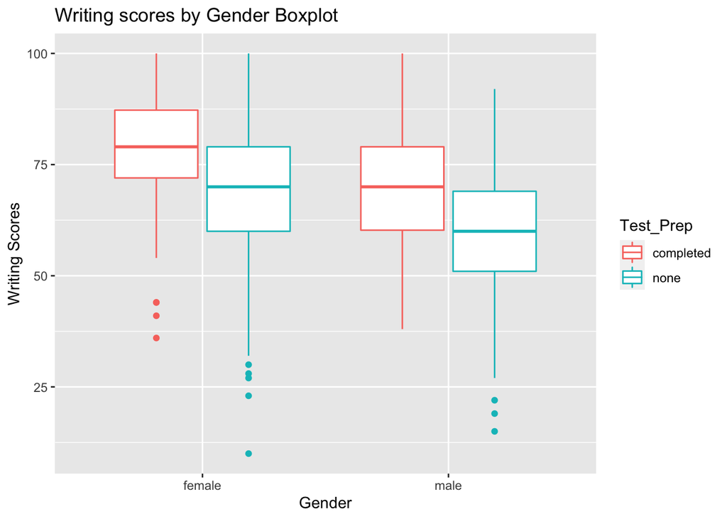

```r
bx <- ggplot(stPerformAvg, aes(Gender, Writing_Score, color = Test_Prep))
bx <- bx + geom_boxplot()
bx <- bx + ggtitle("Writing scores by Gender Boxplot")
bx <- bx + xlab("Gender") + ylab("Writing Scores")
bx
```

#Boxplot of Math scores and test preparation by gender:

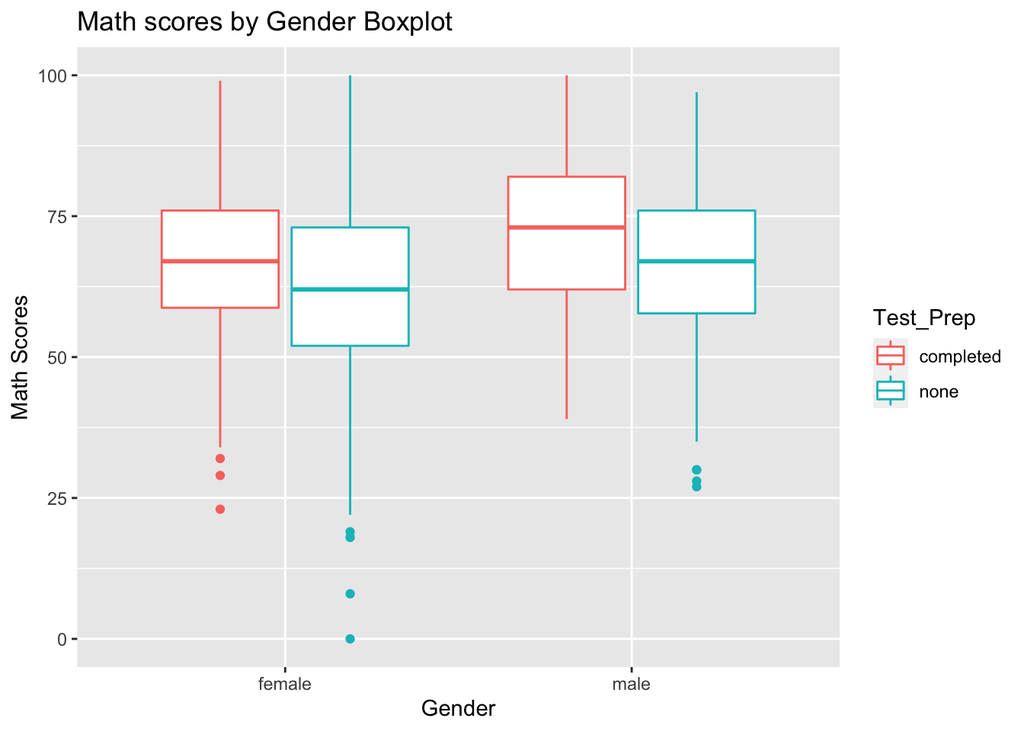

```r
bx1 <- ggplot(stPerformAvg, aes(Gender, Math_Score, color = Test_Prep))
bx1 <- bx1 + geom_boxplot()
bx1 <- bx1 + ggtitle("Math scores by Gender Boxplot")
bx1 <- bx1 + xlab("Gender") + ylab("Math Scores")
bx1
```

#Boxplot of Reading scores and test preparation by gender:

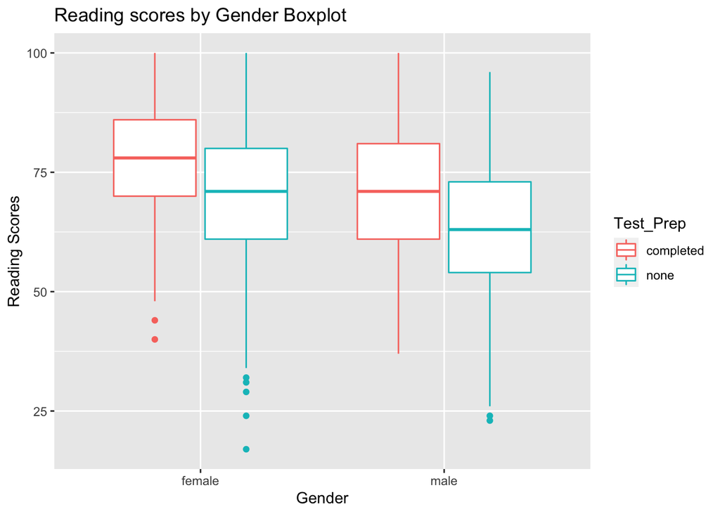

```r
bx2 <- ggplot(stPerformAvg, aes(Gender, Reading_Score, color = Test_Prep))
bx2 <- bx2 + geom_boxplot()
bx2 <- bx2 + ggtitle("Reading scores by Gender Boxplot")
bx2 <- bx2 + xlab("Gender") + ylab("Reading Scores")
bx2
```

#Boxplot of Average scores and test preparation by gender:

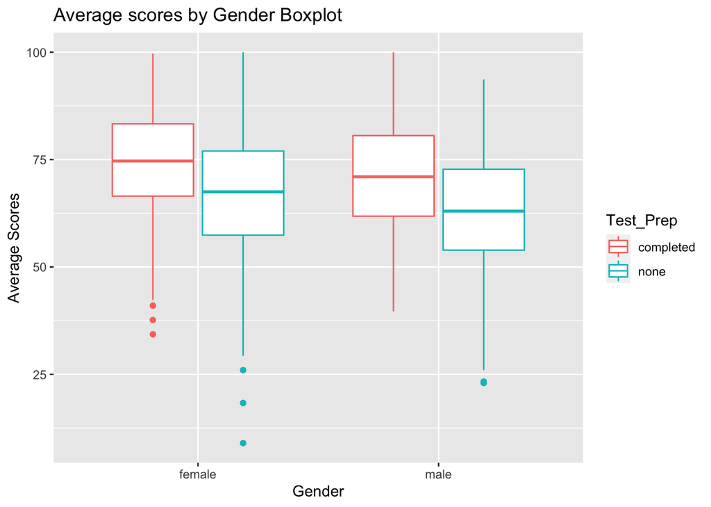

```r
bx3 <- ggplot(stPerformAvg, aes(Gender, avgScore, color = Test_Prep))
bx3 <- bx3 + geom_boxplot()
bx3 <- bx3 + ggtitle("Average scores by Gender Boxplot")
bx3 <- bx3 + xlab("Gender") + ylab("Average Scores")
bx3
```

After visualizing and analizing the boxplots we observed that students who completed the test preparation has better scores in all three exams.

Moreover, it is shown that male students has better scores in math, while female students have in reading and writing.

There are outliers in all three exams.

In average female students did better than male students, and in average students who completed the test preparation did better than the ones who did not.

## Linear regression(Alex Constantinescu):

```r
linearmodel <- lm(Math_Score~avgScore, data= stPerformAvg)
summary(linearmodel)
```

```
##
## Call:
## lm(formula = Math_Score ~ avgScore, data = stPerformAvg)
##
## Residuals:
##      Min       1Q   Median       3Q      Max
## -16.1018  -4.5582  -0.1361   4.3823  16.6130
##
## Coefficients:
##             Estimate Std. Error t value Pr(>|t|)
## (Intercept) -0.13058    0.92056  -0.142    0.887
## avgScore     0.97711    0.01329  73.507   <2e-16 ***
## ---
## Signif. codes:  0 '***' 0.001 '**' 0.01 '*' 0.05 '.' 0.1 ' ' 1
##
## Residual standard error: 5.99 on 998 degrees of freedom
## Multiple R-squared:  0.8441, Adjusted R-squared:  0.8439
## F-statistic:  5403 on 1 and 998 DF,  p-value: < 2.2e-16
```

## Interpretation of the linear regression output:

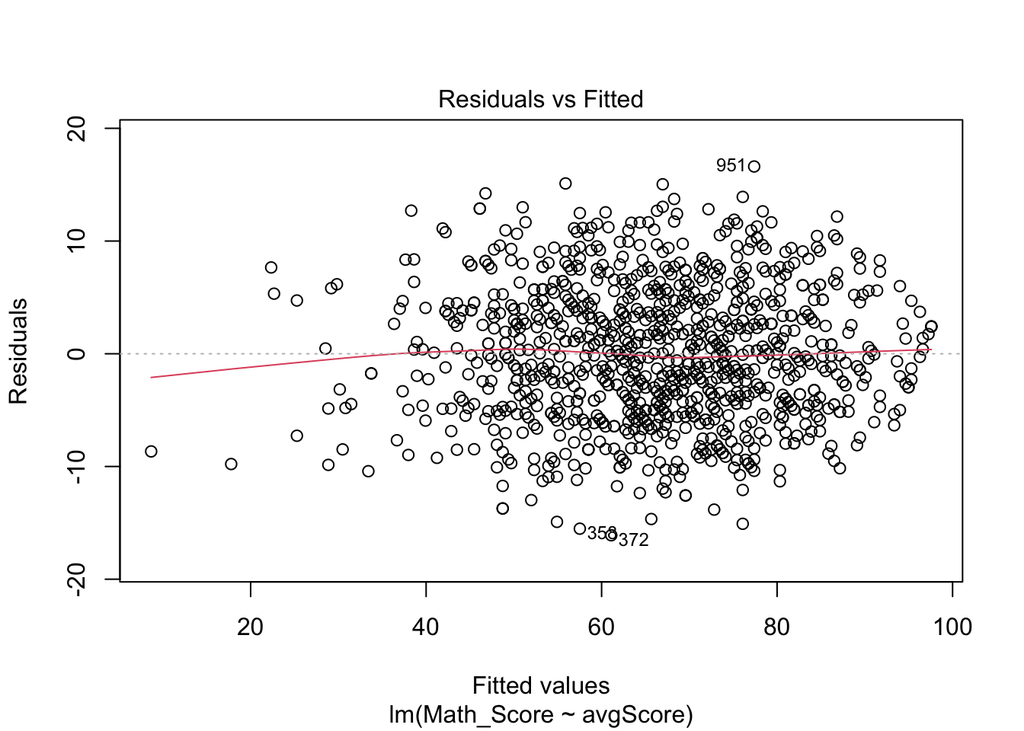

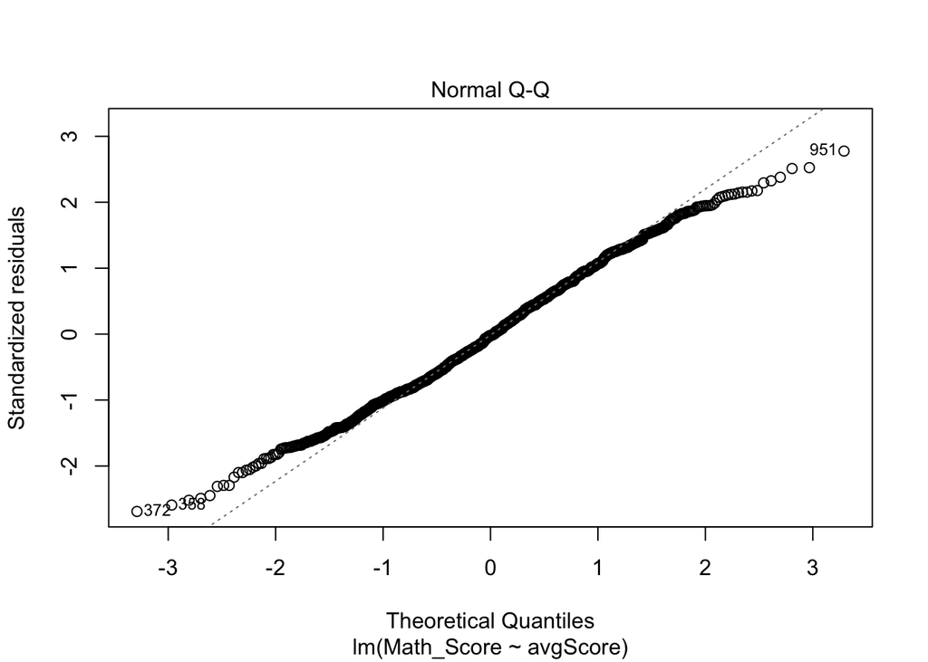

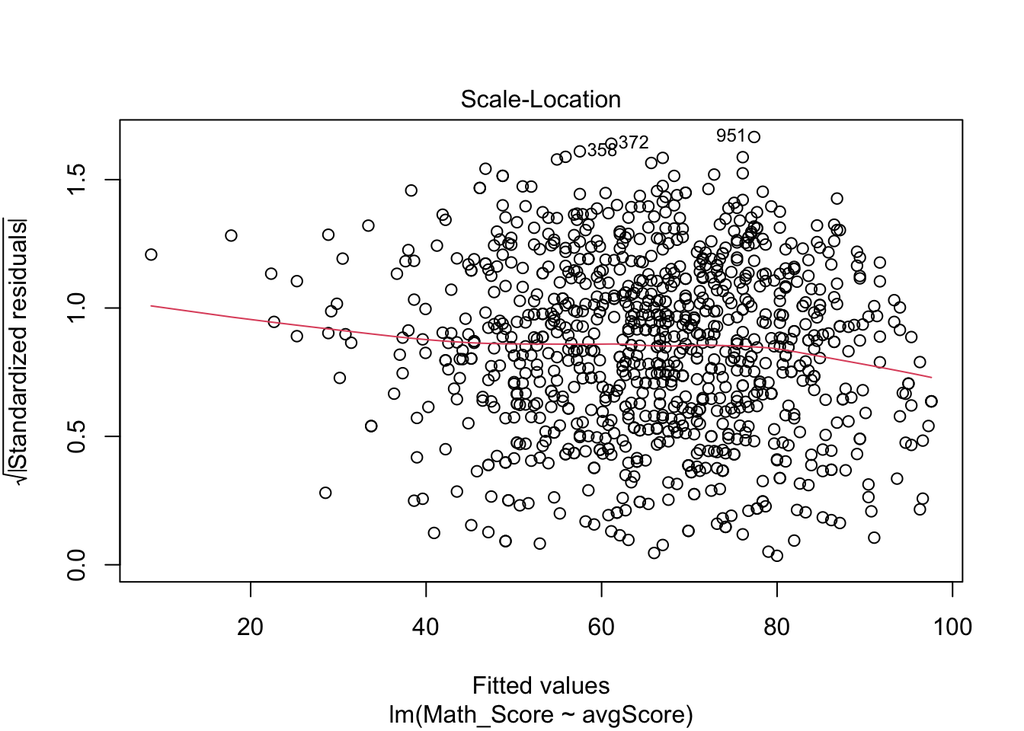

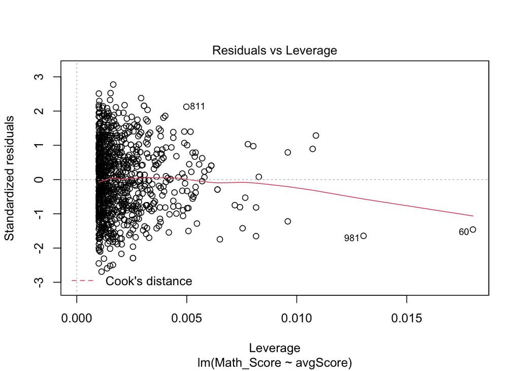

```r
plot(linearmodel)
```

##Linear regression model: assumptions A linear regression makes certain assumptions about the data, which you must check:

1. Homoscedasticity of errors: the variance is homogenous
2. Normality: Errors are normally distributed
3. Independence of observations: data was collected using valid sampling methods, there are no hidden biases or relationships
4. The relationship between X and Y is linear (i.e. the line is straight, not curved)

## Residual analysis:

#1.Residual vs Fitted: Linearity assumption

#2.Q-Q(quantitive-quantile):Normality assumption This plot shows if the residuals are normally distributed. If they are, they follow the straight line in this plot. We see here that apart from some outliers, the values fall on or around the straight line

#3. Scale-Location: Homoscedasticity assumption:

This plot tests for homoscedasticity, i.e. if the residuals have equal variance along the regression line.

In this plot, we have a lot of cases so the variance is equlaity spreaded among the plot.

#4. Residuals vs Leverage

This plot is used to spot influential cases in the model.